# CentrifugalForceCircularOrbit

```python
import numpy as np
import matplotlib.pyplot as plt
```

Start with the motion of a point mass on a circular path. Remember the following identities

$$x=r cos(\theta)\cdot\ \boldsymbol{\hat{i}}\ \ (1)$$$$y=r sin(\theta)\cdot\ \boldsymbol{\hat{j}}\ \ (2)$$

where $\hat{i}$ and $\hat{j}$ are the unit vectors in the x, y direction The velocity of a particle can be decomposed into the x-y direction

$$v = v_{x} + v_{y} = \frac{dx}{dt} + \frac{dy}{dt}\ \ (3)$$

From the chain rule we know

$$ \frac{dz}{dt} = \frac{dz}{d\theta} \frac{d\theta}{dt}\ \ (4)$$

hence $$ v = \frac{dx}{d\theta} \frac{d\theta}{dt} + \frac{dy}{d\theta} \frac{d\theta}{dt} \ \ (5)$$

taking $\frac{d}{d\theta}$ of (1) and (2) and substituting into (5), note that because it is a circle $\frac{dr}{d\theta}=0$

$$ v = r (-sin(\theta)) \frac{d\theta}{dt}\ \boldsymbol{\hat{i}} + r cos (\theta)\frac{d\theta}{dt} \ \boldsymbol{\hat{j}} \ \ (6)$$

We define $\frac{d\theta}{dt}$ as the angular speed $\omega$ with units [$rad\ s^{-1}$] and (6) becomes

$$ \boldsymbol{v} = r\omega [cos (\theta)\ \boldsymbol{\hat{j}} -sin(\theta)\ \boldsymbol{\hat{i}}]\ \ (7)$$

The absolute value of v without direction is the root of the inner-product $\boldsymbol{v} \cdot \boldsymbol{v}$

$$ |\boldsymbol{v}|=v = \sqrt{\boldsymbol{v} \cdot \boldsymbol{v}} = r \omega [cos^{2}(\theta) + sin^{2}(\theta)] = r\omega $$

The direction of v depends on $\omega$ and changes in time. This means $\frac{d\boldsymbol{v}}{dt}$ is not constant and the particle experiences an acceleration.

$$ \boldsymbol{a}=\frac{d\boldsymbol{v}}{dt} = \frac{d}{dt} (r\omega [cos (\theta)\ \boldsymbol{\hat{j}} -sin(\theta)\ \boldsymbol{\hat{i}}]) $$

Assume both r and $\omega$ constant,

$$ \boldsymbol{a}= r\omega [-sin (\theta)\omega \ \boldsymbol{\hat{j}} -cos(\theta)\omega \ \boldsymbol{\hat{i}}]=-r\omega^{2}[cos(\theta)\ \boldsymbol{\hat{i}} + sin (\theta)\ \boldsymbol{\hat{j}}] $$

Where again if we want to know the absolute value we recover; $$a = -r\omega^{2} = -\frac{v^{2}}{r}$$

Hence the force needed to keep the partical of mass m on a circular path by Newtons 2nd law;

$$ F = m * a = -\frac{ m v^{2}}{r}$$

where the direction depends on $\theta$ by $[cos(\theta)\ \boldsymbol{\hat{i}} + sin (\theta)\ \boldsymbol{\hat{j}}]$

```
-0.394784176044 0.394784176044 absolute vs sum Forces
```

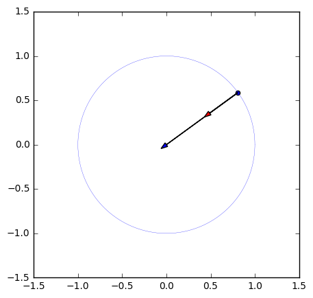

```python
def centrifugalForce(th, m, v, r):


    acceleration_x = -r * (omega**2) * np.cos(th)
    acceleration_y = -r * (omega**2) * np.sin(th)

    Fx = m * acceleration_x
    Fy = m * acceleration_y
    F  = (- m*(v**2)) / float(r)
    print F, np.sqrt(Fx**2 + Fy**2), 'absolute vs sum Forces'
    return Fx, Fy

mass     = 1 #kg
period   = 10 #seconds
radius   = 1  #m
omega    = (2*np.pi*radius)/float(period)
velocity = omega * radius
theta    =   0.2*np.pi  #rad





fig, axes = plt.subplots(1,1, figsize = (5, 5))
#plot circle
angles = np.linspace(0,2*np.pi, 1e4)
axes.plot(np.cos(angles)*radius,np.sin(angles)*radius, lw=0.2)
#plot position point
x = radius * np.cos(theta)
y = radius * np.sin(theta)
axes.scatter(x,y)
#plot direction Force (unit vector length 1) Blue
dx =  -np.cos(theta)
dy =  -np.sin(theta)
axes.arrow(x, y, dx, dy, head_width=0.05, fc='b')
#plot Force with direction Red
Fx, Fy = centrifugalForce(theta, mass, velocity, radius)
axes.arrow(x, y, Fx, Fy, head_width=0.05, fc='r')

plt.show()
```

Spoilers for stars it is the gravitational force of the other star supplying the force needed to keep it in orbit, but then we also need to look at the Center of Mass (segway :p)